# Exploring cellhash data

Josh Shapiro for CCDL

This notebook explores processing cellhash data, separating samples by hashed barcodes.

# Set Up

Libraries:

```r
suppressPackageStartupMessages({
  library(ggplot2)
  library(SingleCellExperiment)
  library(scater)
  library(bluster)
  library(Seurat)
})

theme_set(theme_bw())
```

File paths:

```r
file_dir <- file.path("data", "cellhash")

# test sce files
# These files are the from the Christensen Pool1 sample
unfiltered_file <- file.path(file_dir, paste0(params$lib_id, "_unfiltered.rds"))

# file with sample and barcode info for all samples
pool_file <- file.path(file_dir, "christensen-pools.tsv")
```

# Initial look at SCE objects

The initial mapping that we performed used `alevin-fry` to separately map and quantify RNA-seq reads and hash tag oligos (HTOs), assigning counts to droplets. These results were then read into R and saved as a `SingleCellExperiment` object, combining the two sets of data.

```r
sce_unfiltered <- readRDS(unfiltered_file)
```

These are unfiltered, so we will filter to likely cells with `emptyDropsCellRanger`, which should perform filtering similarly to Cell Ranger.

```r
sce_filtered <- scpcaTools::filter_counts(sce_unfiltered)
# recalculate feature stats
sce_filtered <- scater::addPerFeatureQC(sce_filtered)
altExp(sce_filtered) <- scater::addPerFeatureQC(altExp(sce_filtered))
```

How many cells are in each of these sets?

```r
ncol(sce_unfiltered)
```

```
[1] 145923
```

```r
ncol(sce_filtered)
```

```
[1] 14750
```

(This is an update from previous results, where an earlier emptyDrops version left 80K cells)

### HTO count patterns

When we merge in feature data as part of `scpca-nf` workflow, we add zeros for any cells which do appear in the expression data, but do not appear in cellhash data. While in the case of CITE-seq this may make sense, in the case of cell hashing, a cell with no hash data is going to be impossible to assign.

Let’s see how often that happened here, by looking at the distribution of cell read counts:

```r
cell_metrics <- data.frame(colData(sce_unfiltered)) |>
  tibble::rownames_to_column("cell_barcode") |>
  dplyr::mutate(filter_status = ifelse(
    cell_barcode %in% colnames(sce_filtered),
    "cell",
    "empty"))
```

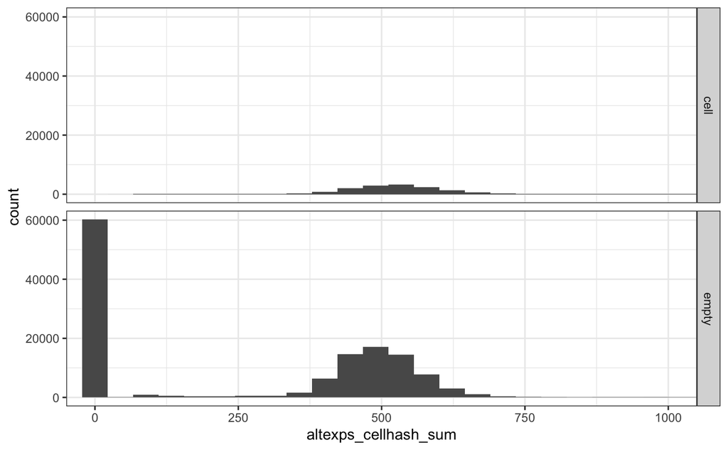

```r
ggplot(cell_metrics, aes(x = altexps_cellhash_sum))+
  geom_histogram(bins = 100) +
  facet_grid(filter_status ~ .) +
  coord_cartesian(xlim = c(0, 1000))
```

There are a large number of cells with cellhash data, but many of those appear to be empty. The empty cells may have a slightly lower mean HTO count, which is a bit heartening. It might be useful to use those as the “ambient” levels for HTO counts?

# The cellhash data

Let’s start looking at the cellhash data.

First we’ll read in the pool data & filter to this experiment

```r
pool_info <- readr::read_tsv(pool_file) |>
  dplyr::filter(scpca_library_id == params$lib_id)
```

```r
# pull the hash data into separate objects
hash_sce <- altExp(sce_filtered, "cellhash")
hash_sce_unfiltered <- altExp(sce_unfiltered, "cellhash")


hash_data <- rowData(hash_sce) |>
  as.data.frame() |>
  tibble::rownames_to_column("HTO") |>
  dplyr::left_join(pool_info, by = c("HTO" = "barcode_id"))
hash_data
```

| HTO | mean | detected | pool_id | scpca_library_id | scpca_sample_id | submitter_id | barcode |
| --- | --- | --- | --- | --- | --- | --- | --- |
| MULTI_1 | 1.605231e+02 | 100.00000000 | Pool_1 | SCPCL000533 | SCPCS000133 | PCNS0601X | GGAGAAGA |
| MULTI_2 | 1.579472e+02 | 100.00000000 | Pool_1 | SCPCL000533 | SCPCS000134 | PCNS0701X | CCACAATG |
| MULTI_3 | 8.328325e+01 | 100.00000000 | Pool_1 | SCPCL000533 | SCPCS000135 | PCNS0801X | TGAGACCT |
| MULTI_4 | 1.346821e+02 | 100.00000000 | Pool_1 | SCPCL000533 | SCPCS000136 | PCNS0901A | GCACACGC |
| MULTI_5 | 4.745763e-04 | 0.04745763 | NA | NA | NA | NA | NA |
| MULTI_6 | 8.135593e-04 | 0.08135593 | NA | NA | NA | NA | NA |
| MULTI_7 | 5.423729e-04 | 0.05423729 | NA | NA | NA | NA | NA |
| MULTI_8 | 1.932203e-02 | 0.96271186 | NA | NA | NA | NA | NA |
| MULTI_9 | 0.000000e+00 | 0.00000000 | NA | NA | NA | NA | NA |
| MULTI_10 | 2.033898e-04 | 0.02033898 | NA | NA | NA | NA | NA |

[output cut: 2 more lines]

This looks as expected: the HTOs that are detected are the ones that should be in this sample.

Let’s reduce our hash data to just those & replace the sample ids:

```r
hash_sce <- hash_sce[!is.na(hash_data$scpca_sample_id),]
rownames(hash_sce) <- hash_data$scpca_sample_id[!is.na(hash_data$scpca_sample_id)]

# also unfiltered
hash_sce_unfiltered <- hash_sce_unfiltered[!is.na(hash_data$scpca_sample_id),]
rownames(hash_sce_unfiltered) <- hash_data$scpca_sample_id[!is.na(hash_data$scpca_sample_id)]
```

Now let’s look at the first 20 cells:

```r
t(counts(hash_sce)[,1:20])
```

```
20 x 4 sparse Matrix of class "dgCMatrix"
                 SCPCS000133 SCPCS000134 SCPCS000135 SCPCS000136
CCCTCTCTCGCTCCTA         177         177          60         129
TCTCCGACATGATCTG         238         202          71         127
CGAGTGCGTCCTATAG         308         179          95         132
GTGACGCTCCGGACGT         109         153          50          92
AGCGATTAGGAACTAT         213         221         121         144
CAGATACAGGTGCCAA         181         187          76         134
GATAGCTCACTTGTGA         188         223          74         139
GATCAGTCATCCGTGG         148         171          78         121
AATAGAGCAACAACAA         164         186          70         132
CTTACCGGTTCCTACC         150         193          74         165
TAGATCGAGGCTCTCG         173         192          48          90
CTATAGGCAAAGAACT         169         203          54          83
CTCAAGACAAATGGCG         141         125          50          84
GAAGCCCGTAGTGATA         169         133          53         113
GTAATGCAGCTAGTTC         137         218          62         149
TTGACCCTCCATCTAT         219         136          64         140
CTGCTCATCAAGAAAC         126         147          78         103
TGGTAGTAGCACAAAT         120         163          63         124
CCTCTCCCAACAGCCC         146         151          51         116
CACGTTCCACTTCATT         173         160         117         124
```

There is some variation there, but the overall counts seem surprisingly similar across cells; it may be difficult to assign cells confidently.

Let’s see if there is much clustering among cells. I will use log1p here for normalization, just for speed.

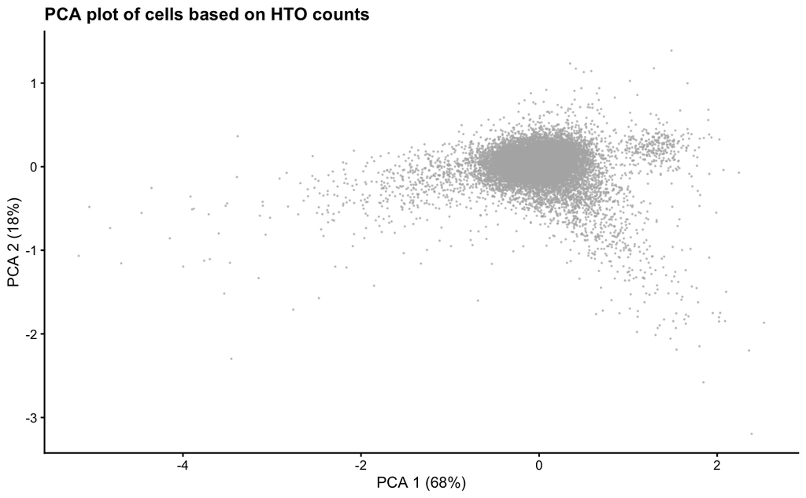

```r
# add a log counts matrix (no normalization)
logcounts(hash_sce) <- log1p(counts(hash_sce))
# calculate pca
hash_sce <- scater::runPCA(hash_sce,
                           ncomponents = 4,
                           BSPARAM=BiocSingular::ExactParam())
# plot pca
scater::plotPCA(hash_sce, point_size = 0.1) +
  ggtitle("PCA plot of cells based on HTO counts")
```

Looks like there may be a few potential clusters there, but overall it is pretty diffuse. We do not see the 4 distinct clusters that we might have expected. I’m not sure how confidently we will be able to deconvolute.

## Assigning cells with `hashedDrops`

First we will run `hashedDrops` with default settings, on the filtered data. This uses a pretty simple method of identifying ambient tag patterns, remove that, and then look for the highest expressed HTO for assignment.

```r
hash_result <- DropletUtils::hashedDrops(hash_sce)

# save results for later
hashdrops_classification <- data.frame(
  cell_barcode = rownames(hash_result),
  hashdrops_maxid = rownames(hash_sce)[hash_result$Best],
  hashdrops_logfc = hash_result$LogFC,
  hashdrops_confident = hash_result$Confident
) |>
  dplyr::mutate(hashdrops_id = ifelse(hashdrops_confident, hashdrops_maxid, NA_character_))
```

How many calls were confidently made?

```r
sum(hash_result$Confident)
```

```
[1] 55
```

Let’s look at the “confident” calls in a bit more depth:

```r
dplyr::count(hashdrops_classification, hashdrops_id)
```

| hashdrops_id | n |
| --- | --- |
| SCPCS000133 | 1 |
| SCPCS000134 | 4 |
| SCPCS000135 | 37 |
| SCPCS000136 | 13 |
| NA | 14695 |

That isn’t so good. Only a handful of calls total cells called of ~14 thousand. It really looks like the background level of all HTOs is too high, or something else is wrong.

We can look at the log fold change value distribution between the best and second best HTO: we would expect to see large values here:

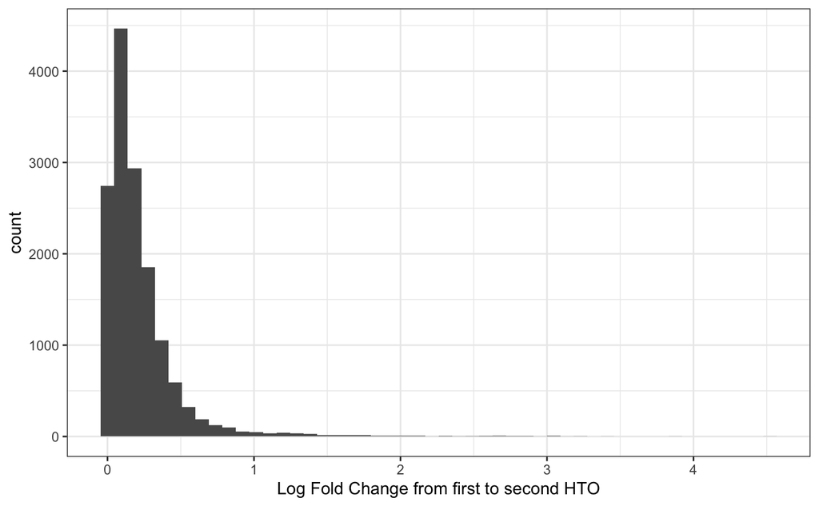

```r
ggplot(hashdrops_classification, aes(x = hashdrops_logfc)) +
  geom_histogram(bins = 50)+
  labs(x = "Log Fold Change from first to second HTO")
```

Not much with even a 2-fold change, which makes it very hard to assign cells confidently. We could lower the threshold, but that seems fraught.

Let’s look at where they are on the PCA plot of the hashed drops:

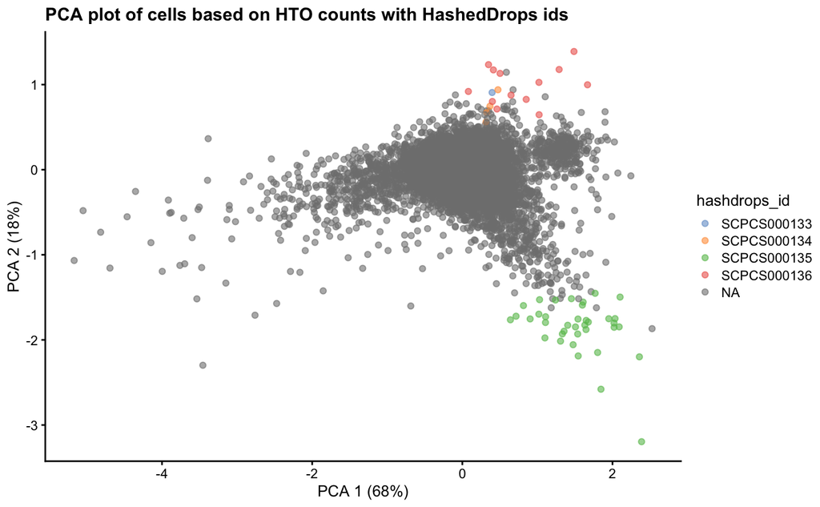

```r
hash_sce$hashdrops_id <- hashdrops_classification$hashdrops_id

scater::plotPCA(hash_sce,
                colour_by = "hashdrops_id") +
  ggtitle("PCA plot of cells based on HTO counts with HashedDrops ids")
```

Not exactly the most comforting assignments!

### Calculating a separate ambient set

We may be able to use the unfiltered data to assign a better ambient profile. Let’s explore that:

First we will pull out the “empty” cells

```r
empty_cells <- ! colnames(hash_sce_unfiltered) %in% colnames(hash_sce)
hash_sce_empty <- hash_sce_unfiltered[,empty_cells]
```

Now we will sum all cells to calculate the ambient profile. There are many cells here with no calls at all, but they will not contribute much at all to the profile so we will ignore those.

```r
ambient_sum <- rowSums(counts(hash_sce_empty))
ambient <- ambient_sum / sum(ambient_sum)
ambient
```

```
SCPCS000133 SCPCS000134 SCPCS000135 SCPCS000136
  0.2964135   0.2935745   0.1554457   0.2545663
```

Now we can try recalculating hash results with this ambient profile:

```r
hash_result2 <- DropletUtils::hashedDrops(hash_sce, ambient = ambient)

sum(hash_result2$Confident)
```

```
[1] 55
```

Are we getting the same cells called confidently?

```r
sum(hash_result$Confident & hash_result2$Confident)
```

```
[1] 55
```

Yup! So that isn’t making a difference.

## Assigning cells with Seurat

```r
# create a Seurat object
seurat_obj <- Seurat::CreateSeuratObject(counts(sce_filtered))
seurat_obj[["HTO"]] <- CreateAssayObject(counts = counts(hash_sce))
seurat_obj <- Seurat::NormalizeData(seurat_obj, assay = "HTO", normalization.method = "CLR")
```

```
Normalizing across features
```

```
  |                                                  | 0 % ~calculating
  |+++++++++++++                                     | 25% ~00s
  |+++++++++++++++++++++++++                         | 50% ~00s
  |++++++++++++++++++++++++++++++++++++++            | 75% ~00s
  |++++++++++++++++++++++++++++++++++++++++++++++++++| 100% elapsed=00s
```

```r
seurat_obj <- Seurat::HTODemux(seurat_obj)
```

```
Cutoff for SCPCS000133 : 162 reads
Cutoff for SCPCS000134 : 162 reads
Cutoff for SCPCS000135 : 76 reads
Cutoff for SCPCS000136 : 138 reads
```

This worked, though with at least one other sample it failed for unknown reasons, so we may not want to rely on it.

I’m also generally uncomfortable with the fact that it seems to call samples based on a relatively simple cutoff for each HTO;

Let’s look at the results:

```r
table(seurat_obj$HTO_classification.global)
```

```
 Doublet Negative  Singlet
    7092     4162     3496
```

So it looks like it did make calls for a much larger number of cells, but the majority are still not being assigned to a sample, and there are a very large number of “doublets.” How confident are those calls?

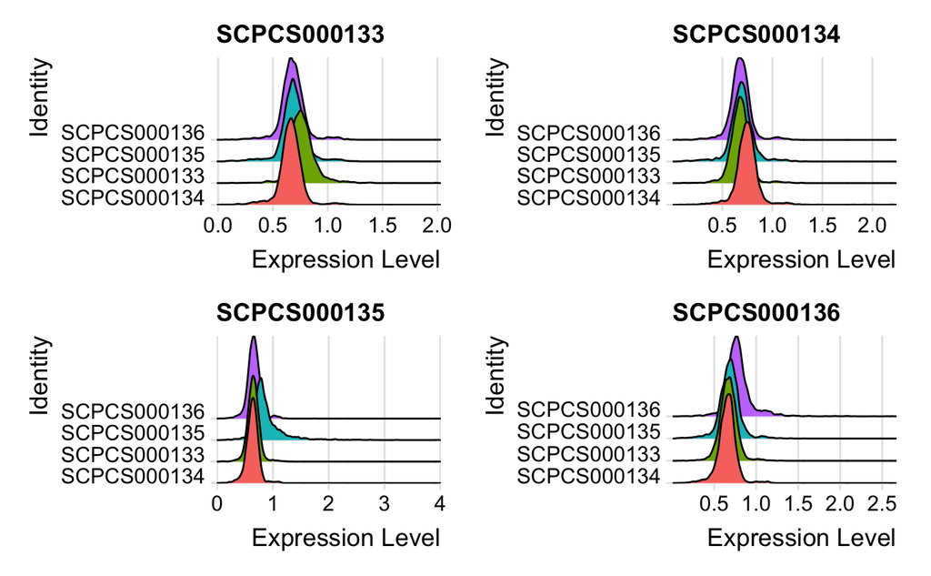

```r
# Group cells based on the max HTO signal
Idents(seurat_obj) <- "HTO_maxID"
RidgePlot(seurat_obj, assay = "HTO", features = rownames(seurat_obj[["HTO"]])[1:4], ncol = 2)
```

I would not call those super-impressive differences. A very slight upward bias for th matching oligo, but that would be expected given the procedure being used to assign the cells requires it.

Overall, I am not confident that the called cells are very reliable based on these data.

Let’s pull out the identities for comparison later.

```r
seurat_classification <- data.frame(
  cell_barcode = colnames(seurat_obj),
  seurat_id = as.character(seurat_obj$hash.ID),
  seurat_maxid = as.character(seurat_obj$HTO_maxID),
  seurat_margin = seurat_obj$HTO_margin
)
```

```r
dplyr::count(seurat_classification, seurat_id)
```

| seurat_id | n |
| --- | --- |
| Doublet | 7092 |
| Negative | 4162 |
| SCPCS000133 | 888 |
| SCPCS000134 | 856 |
| SCPCS000135 | 1029 |
| SCPCS000136 | 723 |

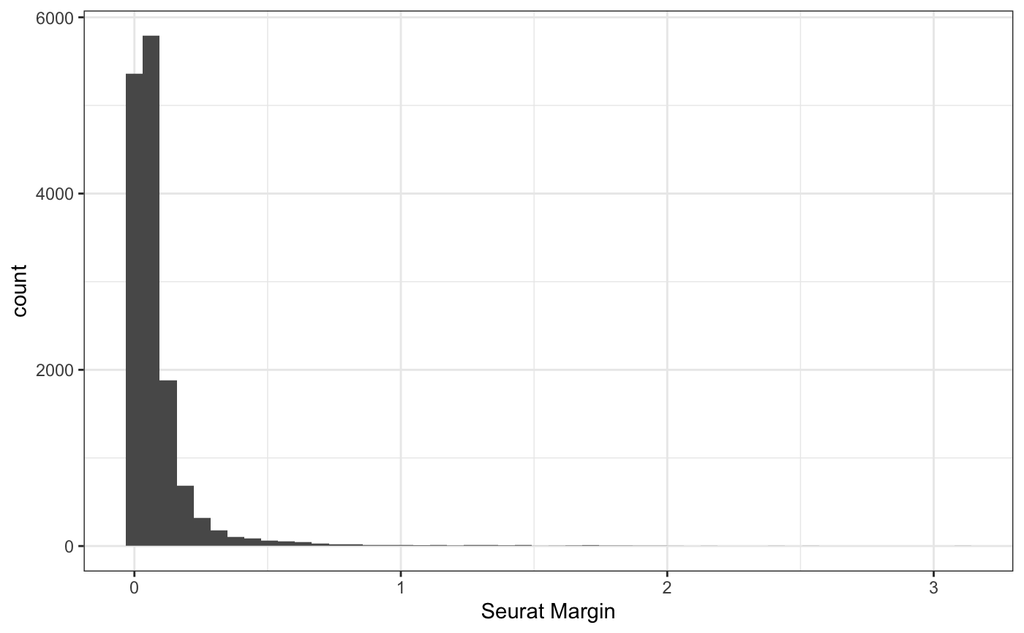

```r
ggplot(seurat_classification, aes(x = seurat_margin)) +
  geom_histogram(bins = 50)+
  labs(x = "Seurat Margin")
```

Let’s look at these calls on our PCA plot as well:

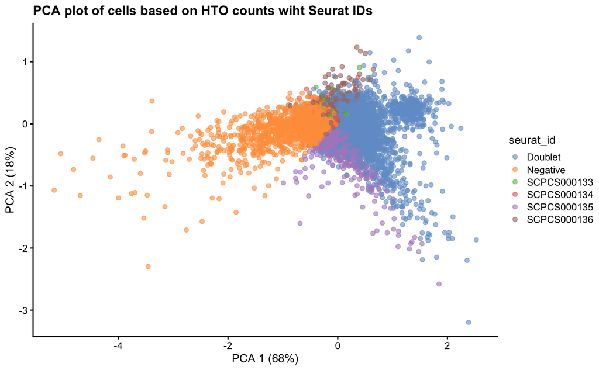

```r
hash_sce$seurat_id <- seurat_classification$seurat_id
scater::plotPCA(hash_sce,
                colour_by = "seurat_id") +
  ggtitle("PCA plot of cells based on HTO counts wiht Seurat IDs")
```

Quite different sets of calls… Not sure what to be most confident in!

# Expression data

Let’s just look quickly at the expression data to see if that looks as we would expect. We will plot some basic cell metrics, including mitochondrial percent.

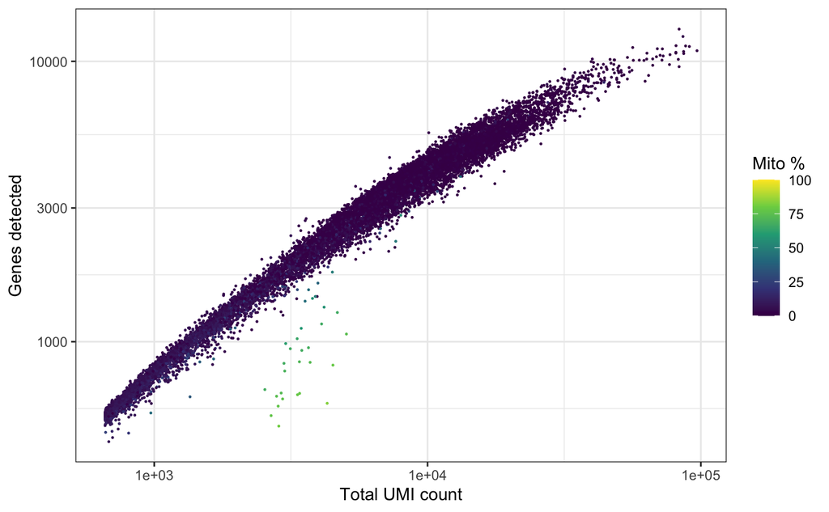

```r
cell_metrics <- colData(sce_filtered)|>
  as.data.frame()|>
  tibble::rownames_to_column("barcode")
ggplot(cell_metrics, aes(x = sum, y = detected, color = subsets_mito_percent)) +
  geom_point(size = 0.2) +
  theme_bw() +
  scale_x_log10() +
  scale_y_log10() +
  scale_color_continuous(type = "viridis", limit = c(0,100)) +
  labs(x = "Total UMI count",
       y = "Genes detected",
       color = "Mito %")
```

Aside from having lots of cells, that looks pretty normal. Let’s add some more aggressive filtering for now.

```r
pass_barcodes <- cell_metrics |>
  dplyr::filter(detected > 500,
                subsets_mito_percent < 10) |>
  dplyr::pull(barcode)
sce_filtered <- sce_filtered[, pass_barcodes]
```

Now we will perform normalization:

```r
qclust <- scran::quickCluster(sce_filtered)
sce_filtered <- sce_filtered |>
  scran::computeSumFactors(clusters = qclust) |>
  scater::logNormCounts()
```

And some dimension reduction with UMAP:

```r
sce_filtered <- sce_filtered |>
  scater::runPCA() |>
  scater::runUMAP()
```

Plot the UMAP results:

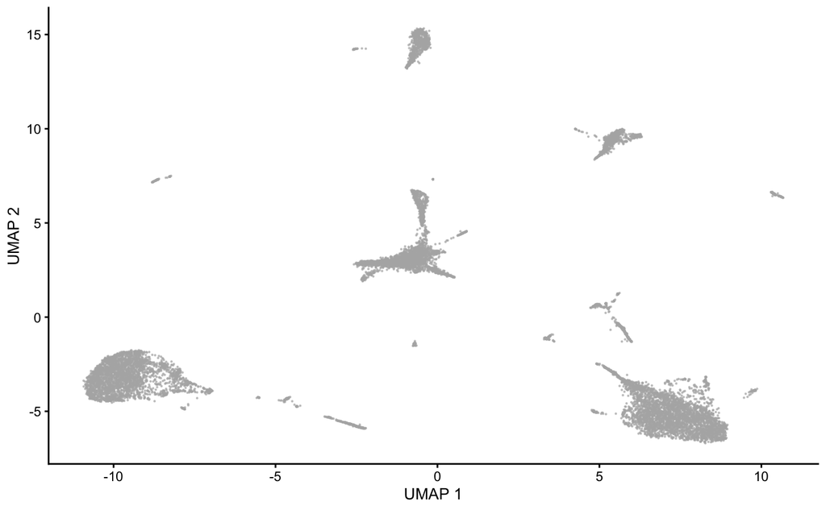

```r
scater::plotUMAP(sce_filtered, point_size = 0.1)
```

There does seem to be some normal-ish looking structure there, but of course without any context, there is little to interpret! Are the clusters different cell types or different samples?

### Add in the classification info

Let’s merge in all of the classification info we have from earlier:

```r
# make sure order is correct in classification table
hash_class <- data.frame(cell_barcode = colnames(sce_filtered)) |>
  dplyr::left_join(hashdrops_classification, by = "cell_barcode")|>
  dplyr::left_join(seurat_classification, by = "cell_barcode") |>
  dplyr::mutate(seurat_id = ifelse(seurat_id %in% c("Doublet","Negative"), NA_character_, seurat_id))

# add columns to sce
sce_filtered$hashdrops_id = hash_class$hashdrops_id
sce_filtered$seurat_id = hash_class$seurat_id
```

Plot the UMAP results with classifications:

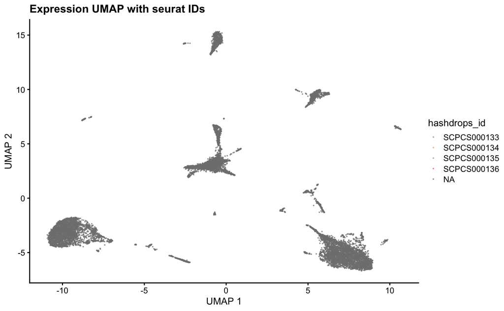

```r
### hashdrops
scater::plotUMAP(sce_filtered, point_size = 0.1, colour_by = "hashdrops_id") +
  ggtitle("Expression UMAP with seurat IDs")
```

They are in there, but too few to see!

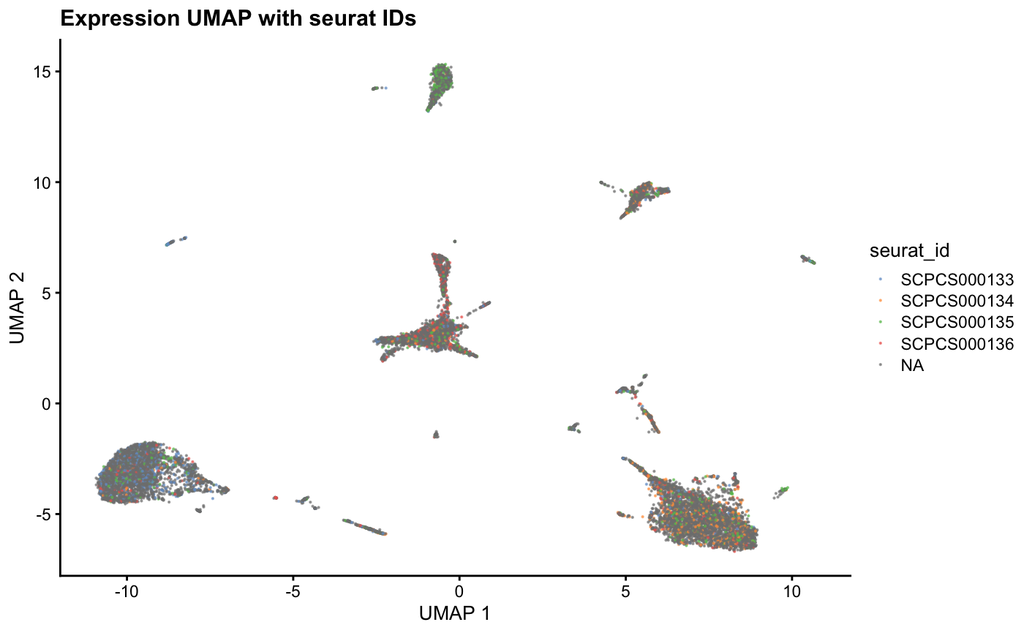

```r
### seurat
scater::plotUMAP(sce_filtered, point_size = 0.1, colour_by = "seurat_id") +
  ggtitle("Expression UMAP with seurat IDs")
```